# ISOM3390 Final Project

# Group 10

### PUN, Sanford Harrap 20607555

### WONG, Wing Kin 20504727

# Setup

```r
library(tidyverse)
library(rvest)
library(RSelenium)
library(tidytext)
```

# Scraping

First, run the command java -Dwebdriver.chrome.driver=chromedriver.exe -jar selenium-server-standalone-3.141.59.jar to start the server.

```r
# Connect to the running server
remDr <- remoteDriver(remoteServerAddr = "localhost", port = 4445L, browserName = "chrome")  # 'firefox', 'internet explorer', 'iphone', etc.
# str(remDr, max.level = 1)

# Start the browser
remDr$open(silent = TRUE)

# Get the status of the server
remDr$getStatus() %>% str()

# Navigate to the url
remDr$navigate("https://www.imdb.com/chart/moviemeter?sort=rk,asc&mode=simple&page=1")
```

For each movie, control the server to click into the movie title and collect necessary data

```r
# First, create a tibble with movie titles and their hyperlinks
page_source <- remDr$getPageSource()[[1]] %>% read_html()
movies_table <- page_source %>% html_node(".lister-list")
movies_titles <- movies_table %>% html_nodes("a") %>% html_text(trim = TRUE) %>%
    .[seq(2, 200, 2)]
movies_urls <- movies_table %>% html_nodes("a") %>% html_attr("href") %>% .[seq(2,
    200, 2)] %>% str_c("https://www.imdb.com", .)

movies <- tibble(title = movies_titles, url = movies_urls)
movies %>% head
```

Store the reviews of each movie into a big tibble “reviews”.

```r
# Create a tibble to store user reviews
reviews <- tibble(movie = character(), rating = numeric(), review_header = character(),
    review = character())

# Next, use a for loop along the movies tibble to collect 100 user reviews for
# each movie
for (i in seq_along(movies$title)) {
    # Extract the id that IMDb assigns to each movie
    movie_id <- movies$url[i] %>% str_extract("/title/.+/")

    # Navigate to the user reviews page
    reviews_url <- movie_id %>% str_c("https://www.imdb.com", ., "reviews?ref_=tt_urv")
    remDr$navigate(reviews_url)

    # Wait for loading
    Sys.sleep(3)

    # Locate the hide spoilers checkbox
    hideSpoilers <- remDr$findElement(using = "css", value = ".lister-widget-sprite.lister-checkbox")
    # class(hideSpoilers)
    hideSpoilers$clickElement()  # Tick the checkbox to hide spoilers

    Sys.sleep(3)

    # Find the total number of reviews
    page_source <- remDr$getPageSource()[[1]] %>% read_html()
    num_reviews <- page_source %>% html_node(".lister") %>% html_node(".header") %>%
        html_nodes("span") %>% .[1] %>% html_text(trim = TRUE) %>% str_extract(".+ ") %>%
        str_sub(end = -2) %>% gsub(",", "", .) %>% as.numeric()

    if (num_reviews <= 0) {
        next
    }

    # Determine the number of clicks on the show more button.  At start the page
    # shows 25 reviews (or less).  Each click loads 25 more.
    num_clicks <- 3
    if (num_reviews <= 25) {
        num_clicks <- 0
    } else if (num_reviews <= 50) {
        num_clicks <- 1
    } else if (num_reviews <= 75) {
        num_clicks <- 2
    } else {
        num_clicks <- 3
    }

    if (num_clicks > 0) {
        # Perform the determined number of clicks
        for (click in 1:num_clicks) {
            # Locate the loadmore button
            loadMore <- remDr$findElement(using = "css", value = ".ipl-load-more__button")
            loadMore$clickElement()
            Sys.sleep(3)  # Wait for loading
        }
    }

    # Expand all long review
    expanders <- remDr$findElements(using = "css", value = ".expander-icon-wrapper.show-more__control")
    if (expanders %>% length > 0) {
        for (j in seq_along(expanders)) {
            expanders[[j]]$clickElement()
        }
    }

    # Locate the list containing all user reviews
    page_source <- remDr$getPageSource()[[1]] %>% read_html()
    whole_list <- page_source %>% html_nodes(".lister-list")
    if (whole_list %>% length == 0) {
        # List not found
        next
    }
    whole_list <- whole_list[1] %>% html_nodes(".lister-item.mode-detail.imdb-user-review.collapsable")

    if (whole_list %>% length == 0) {
        # No review elements in the list
        next
    }

    # For each piece of user review, collect the rating and the review
    review_count <- 1  # when this count reaches 101, break the loop
    for (j in seq_along(whole_list)) {
        if (review_count >= 101) {
            break
        }

        # Obtain the rating
        rating <- NA
        # Check if a rating exists
        if (whole_list[j] %>% html_nodes(".rating-other-user-rating") %>% length >
            0) {
            rating <- whole_list[j] %>% html_node(".rating-other-user-rating") %>%
                html_node("span") %>% html_text(trim = TRUE) %>% as.numeric()
        }

        # Obtain the review header
        header <- NA
        # Check if a header exists
        if (whole_list[j] %>% html_nodes(".title") %>% length > 0) {
            header <- whole_list[j] %>% html_node(".title") %>% html_text(trim = TRUE)
        }

        # Obtain the review content
        content <- NA
        # Check if content exists (play safe)
        if (whole_list[j] %>% html_nodes(".text.show-more__control") %>% length >
            0) {
            content <- whole_list[j] %>% html_node(".text.show-more__control") %>%
                html_text(trim = TRUE)
        }

        reviews <- reviews %>% add_row(movie = movies$title[i], rating = rating,
            review_header = header, review = content)

        review_count <- review_count + 1
    }

}
```

### Not Enough Reviews

It is worth mentioning that even though we are tasked to collect 100 reviews per movie, but the total number of reviews we extracted is less than 10000. This is due to the fact that some movies have less than 100 reviews or even no reviews at all. In our analysis, we collect up to 100 reviews from each movie, without putting too much thoughts into those with under 100, as it does not affect the sentiment analysis later on. (In short, for those movies with less than 100 reviews, we simply extracted all.)

Write the reviews tibble into a csv file.

```r
reviews %>% write.csv("reviews.csv")
```

That concludes the process of scraping reviews.

# Analysis

Read the reviews from the csv file.

```r
reviews <- read.csv("reviews.csv")
```

There are 4334 positive reviews and 2756 negative reviews. Let’s sample 2500 Positive reviews and 2500 negative reviews and store it to reviews_sample

```r
reviews_pos <- reviews %>% filter(rating >= 6) %>% head(2500)
reviews_neg <- reviews %>% filter(rating <= 5) %>% head(2500)

reviews_sample <- rbind(reviews_pos, reviews_neg)

reviews_sample %>% head
```

```
##   X.1 X       movie rating                                   review_header
## 1   1 1 Dil Bechara     10               Love is more important than life.
## 2   2 2 Dil Bechara     10                                        Fabulous
## 3   3 3 Dil Bechara     10  He left a mark and will always be remembered !
## 4   4 4 Dil Bechara     10                         What a masterpiece!!!!!
## 5   5 5 Dil Bechara     10 Such an emotional tribute to a wonderful actor.
## 6   6 6 Dil Bechara     10                                  One last time!
##                                                                                                                                                                                                                                                                                                          …
## 1                                                                                                                                                                                                                                                                                                        …
## 2                                                                                                                                                                                                                                                                                                        …
## 3 Dear Manny/Augustas/Sushant Singh Rajput\nyou did leave a mark, you left all your viewers speechless.\nBe it in the reel world or the real world.\nYou were the most amazing character and I enjoyed you act, and sobbed at the same time, watching you smile and crack jokes made me so emotional.\nHo…
## 4                                                                                                                                                                                                                                                                                                        …
## 5                                                                                                                                                                                                 There is no better way to give tribute to a genuinely amazing actor. The film was pretty emotional and …
## 6                                                                                                                                                                                                                                                                                                        …
```

Now, we have to do some preprocessing. Let’s tokenize and remove the stop-word in the review

```r
reviews_sample_token <- reviews_sample %>% unnest_tokens(word, review) %>% filter(!str_detect(word,
    "^[0-9]*$"))
reviews_sample_no_stopword <- reviews_sample_token %>% anti_join(stop_words, by = "word")
reviews_sample_bing <- reviews_sample_no_stopword %>% inner_join(get_sentiments("bing"),
    by = "word")
reviews_sample_bing %>% head
```

```
##   X.1 X       movie rating                     review_header     word sentiment
## 1   1 1 Dil Bechara     10 Love is more important than life.   finest  positive
## 2   1 1 Dil Bechara     10 Love is more important than life. nepotism  negative
## 3   1 1 Dil Bechara     10 Love is more important than life.  perfect  positive
## 4   2 2 Dil Bechara     10                          Fabulous      cry  negative
## 5   2 2 Dil Bechara     10                          Fabulous   strong  positive
## 6   2 2 Dil Bechara     10                          Fabulous  capable  positive
```

We have a bag of words now. Let’s predict the sentiment according to those word, and evaluate the outcomes by contrasting with actual rating. Since some of the reviews just contain a bunch of stopwords, those reviews is removed in the preprocessing.

```r
reviews_predict <- reviews_sample_bing %>% count(X, movie, review_header, rating,
    sentiment) %>% pivot_wider(names_from = sentiment, values_from = n, values_fill = 0) %>%
    mutate(sentiment = round(positive * 10/(positive + negative)), diff = sentiment -
        rating)

reviews_predict %>% head
```

```
## # A tibble: 6 x 8
##       X movie   review_header           rating negative positive sentiment  diff
##   <int> <chr>   <chr>                    <int>    <int>    <int>     <dbl> <dbl>
## 1     1 Dil Be~ Love is more important~     10        1        2         7    -3
## 2     2 Dil Be~ Fabulous                    10        4        2         3    -7
## 3     3 Dil Be~ He left a mark and wil~     10        3       10         8    -2
## 4     4 Dil Be~ What a masterpiece!!!!!     10        2        4         7    -3
## 5     5 Dil Be~ Such an emotional trib~     10        1        3         8    -2
## 6     6 Dil Be~ One last time!              10        1        2         7    -3
```

Let’s evaluate the outcomes by contrasting with actual rating. 677 reviews are perfectly predicted.

```r
reviews_predict %>% filter(diff == 0) %>% inner_join(reviews, by = c("X", "movie",
    "review_header", "rating")) %>% select("X", "review", "rating", "negative", "positive",
    "sentiment", "diff") %>% head
```

```
## # A tibble: 6 x 7
##       X review                          rating negative positive sentiment  diff
##   <int> <chr>                            <int>    <int>    <int>     <dbl> <dbl>
## 1    10 The best movie and I was in my~     10        0        2        10     0
## 2    12 Don't know what to write just ~     10        0        1        10     0
## 3    16 Really just would bring tears ~     10        0        2        10     0
## 4    19 Fantastic movie, watched this ~     10        0        1        10     0
## 5    21 The movie was absolutely fanta~     10        0        1        10     0
## 6    22 I Smiled, Laughed, Loved and I~     10        0        3        10     0
```

```r
reviews_predict %>% filter(diff < -5) %>% inner_join(reviews, by = c("X", "movie",
    "review_header", "rating")) %>% select("X", "review", "rating", "negative", "positive",
    "sentiment", "diff") %>% head
```

```
## # A tibble: 6 x 7
##       X review                          rating negative positive sentiment  diff
##   <int> <chr>                            <int>    <int>    <int>     <dbl> <dbl>
## 1     2 "This is the only Indian movie~     10        4        2         3    -7
## 2     9 "Its life\nThe one who want to~     10        1        0         0   -10
## 3    11 "A must watch movie... This mo~     10        2        1         3    -7
## 4    15 "A must watch movie... This mo~     10        2        1         3    -7
## 5    18 "If you had seen The orginal g~     10        4        0         0   -10
## 6    20 "Heart wrenching movie unbaise~     10        2        0         0   -10
```

## Evaluation

The current metric of sentiment for each review is very simple: the percentage of positive words in the review, rid of any stop words. We observe the trend that many reviewers gave some criticism (containing negative words) even though they gave 10/10. Under the current metric, negative words create huge impacts on the sentiment prediction.

The scale of sentiment scores currently is relatively intolerant to differences. For instance, a score of 9 and a score of 10 are inherently similar to humans, but the current system does not tolerate the small difference. Let’s try to evaluate with the ROC score. Here, we do a binary classification. If the predict score is higher than 5, then it is “positive”, otherwise, it is “negative”, thus increasing the tolerance.

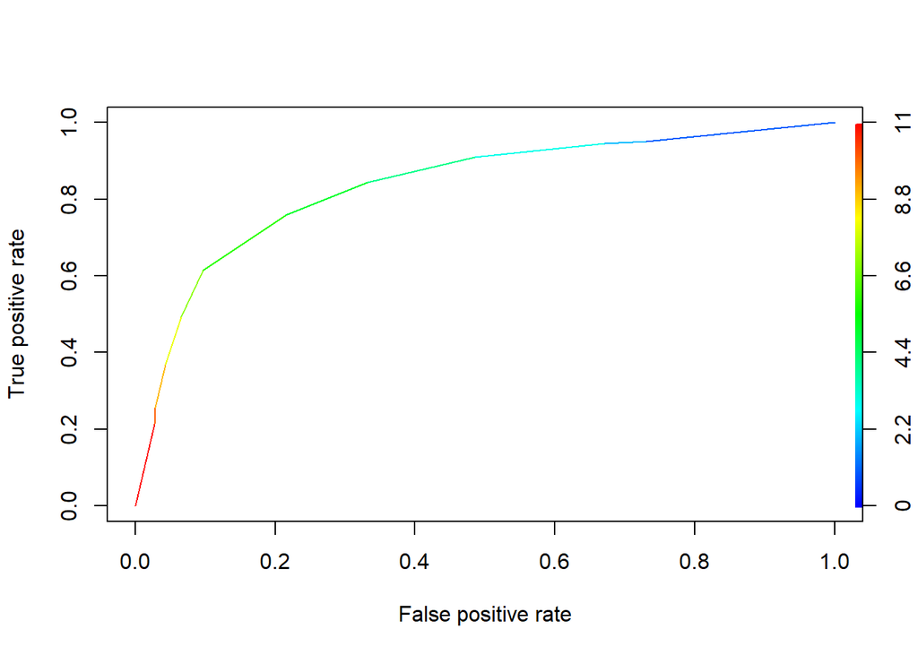

```r
library(ROCR)
pred <- prediction(reviews_predict$sentiment, ifelse(reviews_predict$rating > 5,
    1, 0))
perf <- performance(pred, "tpr", "fpr")
plot(perf, colorize = TRUE)
```

As we can see from the graph, the Area Under Curve (AUC) under this binary scale is large, implying a high accuracy.

Another reason is that English words convey different meanings depending on the context. Reviewers might have used negative words without knowing it, or vice versa. A good example is the word “funny”. A user might have praised a comedy movie for it being funny, but actually funny is considered to be a negative word, thus resulting in a false negative analysis.

In the English language, double negative is a common way to express appreciation (e.g. “not bad”), but it is very tricky to the program, as the program considers each word separately. Therefore, the program can be improved by using n-grams: consider more consecutive words instead of only one at a time. This way the grammar and order of words, which are particularly important in languages such as English, will be considered in the analysis.

```r
freq_words <- reviews_sample_bing %>% select("word", "sentiment", "rating") %>% group_by(word,
    sentiment, rating) %>% summarise(count = n())
freq_words <- freq_words[order(freq_words$count, decreasing = TRUE), ]
```

The 5 most commonly-used negative word.

```r
freq_words_neg <- freq_words %>% filter(sentiment == "negative") %>% select("word",
    "sentiment", "count") %>% summarise(sum = sum(count))
freq_words_neg <- freq_words_neg[order(freq_words_neg$sum, decreasing = TRUE), ]
freq_words_neg <- freq_words_neg %>% head(5)
freq_words_neg
```

```
## # A tibble: 5 x 3
## # Groups:   word [5]
##   word   sentiment   sum
##   <chr>  <chr>     <int>
## 1 bad    negative    874
## 2 plot   negative    874
## 3 boring negative    482
## 4 hard   negative    335
## 5 waste  negative    318
```

The 5 most commonly-used positive word.

```r
freq_words_pos <- freq_words %>% filter(sentiment == "positive") %>% select("word",
    "sentiment", "count") %>% summarise(sum = sum(count))
freq_words_pos <- freq_words_pos[order(freq_words_pos$sum, decreasing = TRUE), ]
freq_words_pos <- freq_words_pos %>% head(5)
freq_words_pos
```

```
## # A tibble: 5 x 3
## # Groups:   word [5]
##   word    sentiment   sum
##   <chr>   <chr>     <int>
## 1 love    positive    932
## 2 fun     positive    424
## 3 amazing positive    399
## 4 pretty  positive    336
## 5 perfect positive    329
```

Below are the graph

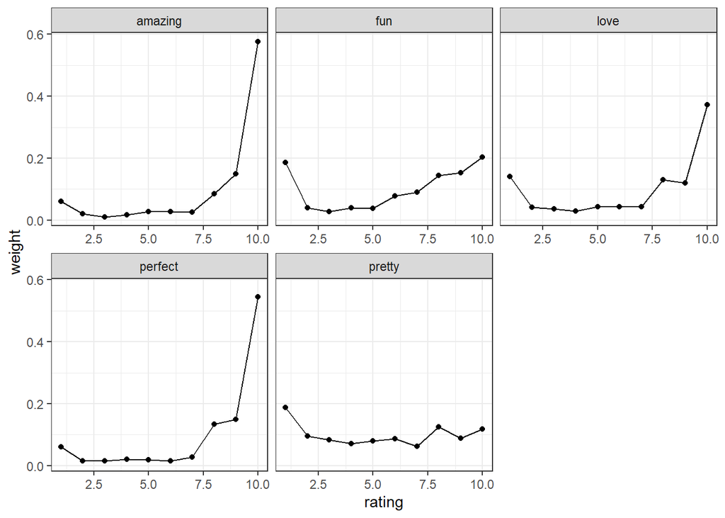

```r
data <- freq_words %>% inner_join(freq_words_pos, by = "word", "sentiment") %>% mutate(weight = count/sum)
ggplot(data, aes(rating, weight)) + geom_point() + geom_line() + theme_bw() + facet_wrap(~word,
    ncol = 3, scales = "free_x")
```

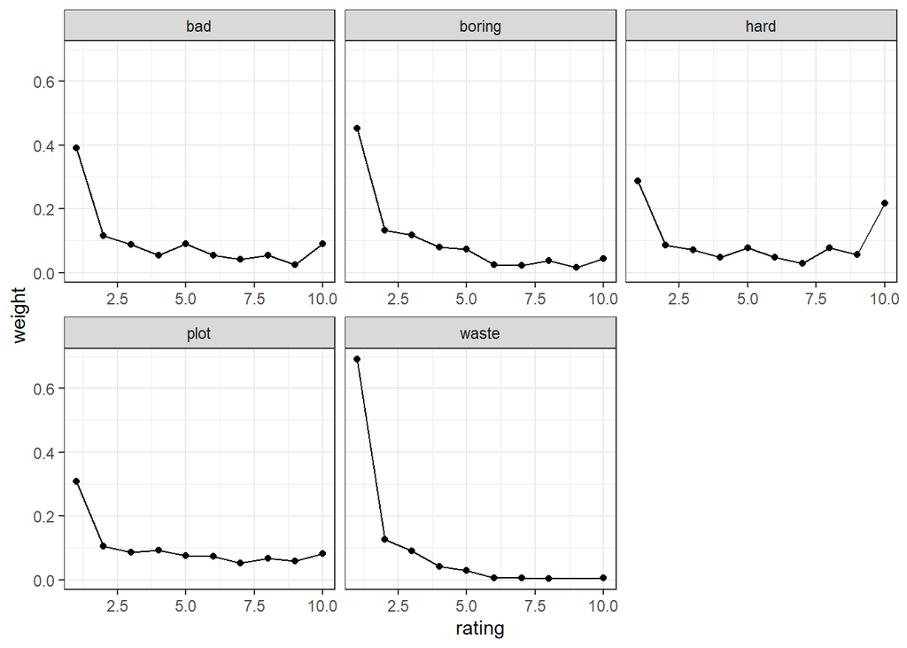

```r
data <- freq_words %>% inner_join(freq_words_neg, by = "word", "sentiment") %>% mutate(weight = count/sum)
ggplot(data, aes(rating, weight)) + geom_point() + geom_line() + theme_bw() + facet_wrap(~word,
    ncol = 3, scales = "free_x")
```